# Introduction to data.table - completed course

Jan Malik

06 April 2018

# Avant de commencer

Le package `data.table` permet de manipuler de façon très efficace des `data.frame` pouvant faire plusieurs centaines de gigooctets en RAM. Pour cela, à l’instar de ce que propose `dplyr` et sa classe `tibble`, une nouvelle classe est proposée : les `data.table`.

Avant de commencer, il faut charger le package après, le cac échéant, l’avoir installé.

```r
library(data.table)
```

Pour créer un `data.table` on peut soit utiliser la fonction `fread()` qu’on a déjà étudiée brièvement soit utiliser l’une des deux fonctions `data.table()` (qui permet de créer un `data.table`directement), soit la fonction `as.data.table()` qui permet de convertir un objet existant en `data.table` (à condition qu’une méthode soit proposée par l’objet en question).

Par exemple

```r
df <- data.frame(x=1:8, y=LETTERS[1:8])
DT1 <- as.data.table(df)
DT2 <- data.table(x=1:8, y=LETTERS[1:8])
DT1
```

| x | y |
| --- | --- |
| 1 | A |
| 2 | B |
| 3 | C |
| 4 | D |
| 5 | E |
| 6 | F |
| 7 | G |
| 8 | H |

```r
DT2
```

| x | y |
| --- | --- |
| 1 | A |
| 2 | B |
| 3 | C |
| 4 | D |
| 5 | E |
| 6 | F |
| 7 | G |
| 8 | H |

# Principes généraux

Le package `data.table` offre une syntaxe de manipulation des données très puissante. Là où `dplyr` vise la généralité (manipulation de `tibble` en local ou de bases des données SQL distantes) et la simplicité, `data.table` vise la performance avant tout et la souplesse de la syntaxe.

Pour donner des exemples nous allons créer un `data.frame` qui comprend deux variables quantitatives et une variable qualitative.

```r
x <-rnorm(20)
y <- 2*x+1+0.01*rnorm(20)
DT <- data.table(
  x = x,
  y = y,
  z = rep(c("a", "b"), 10)
)
DT
```

| x | y | z |
| --- | --- | --- |
| -1.1988600 | -1.4045196 | a |
| 1.1499418 | 3.3071507 | b |
| -1.9443946 | -2.8846166 | a |
| -0.3191848 | 0.3644180 | b |
| -0.6287304 | -0.2611590 | a |
| 1.8109506 | 4.6054705 | b |
| -0.2455627 | 0.5172235 | a |
| -1.1424374 | -1.2892339 | b |
| 1.4309745 | 3.8417864 | a |
| 0.7673159 | 2.5297265 | b |

[output cut: 10 more lines]

La syntaxe générale de manipulation d’un `data.table` est la suivante :

```r
DT[i, j, by]
```

où l’on peut dire (pour simplifier un peu) que :

- `i` permet la sélection de lignes ;
- `j` permet la sélection de colonnes ;
- `by` permet de regrouper suivant certaines variables les opérations effectuées.

On va voir en réalité, et progressivement, que les opérations possibles sont extêmement riches.

## Informations

On peut connaître la dimension d’un `data.table` à l’aide de la commande `dim()` et le nom des variables à l’aide de la commande `names()` :

```r
names(DT)
```

```
[1] "x" "y" "z"
```

## Manipulation des lignes

On sélectionne des lignes de la façon suivantes :

```r
DT[2:3]
```

| x | y | z |
| --- | --- | --- |
| 1.149942 | 3.307151 | b |
| -1.944395 | -2.884617 | a |

ou pour être plus proche de la syntaxe des `data.frame` avec la syntaxe équivanlente :

```r
DT[2:3,]
```

| x | y | z |
| --- | --- | --- |
| 1.149942 | 3.307151 | b |
| -1.944395 | -2.884617 | a |

On peut passer n’importe que vecteur de positions :

```r
DT[c(4,7)]
```

| x | y | z |
| --- | --- | --- |
| -0.3191848 | 0.3644180 | b |
| -0.2455627 | 0.5172235 | a |

La dernière ligne est accessible grâce à la variable `.N` (définie dans l’environement du `data.table` `DT` et qui comprend le nombre de lignes de `DT` :

```r
DT[.N]
```

| x | y | z |
| --- | --- | --- |
| 1.02817 | 3.037883 | b |

On peut même créer un `data.table` qui répète un certain nombre de fois la première ligne (par exemple) :

```r
DT[rep(1,7)]
```

| x | y | z |
| --- | --- | --- |
| -1.19886 | -1.40452 | a |
| -1.19886 | -1.40452 | a |
| -1.19886 | -1.40452 | a |
| -1.19886 | -1.40452 | a |
| -1.19886 | -1.40452 | a |
| -1.19886 | -1.40452 | a |
| -1.19886 | -1.40452 | a |

## Sélection de colonnes

C’est l’opération la plus simple permise par l’argument `j` (qui se révèlera bien plus puissant). Il suffit de passer une liste qui contient les noms des colonnes que l’on souhaite sélectionner.

```r
DT[, list(x, y)]
```

| x | y |
| --- | --- |
| -1.1988600 | -1.4045196 |
| 1.1499418 | 3.3071507 |
| -1.9443946 | -2.8846166 |
| -0.3191848 | 0.3644180 |
| -0.6287304 | -0.2611590 |
| 1.8109506 | 4.6054705 |
| -0.2455627 | 0.5172235 |
| -1.1424374 | -1.2892339 |
| 1.4309745 | 3.8417864 |
| 0.7673159 | 2.5297265 |

[output cut: 10 more lines]

On remarque la virgule qui indique que l’argument `i` est absent. On peut sélectionner une seule variable :

```r
DT[,list(x)]
```

| x |
| --- |
| -1.1988600 |
| 1.1499418 |
| -1.9443946 |
| -0.3191848 |
| -0.6287304 |
| 1.8109506 |
| -0.2455627 |
| -1.1424374 |
| 1.4309745 |
| 0.7673159 |

[output cut: 10 more lines]

On remarque que le résultat n’est pas le même si l’on passe seulement `x` au lieu de `list(x)`. On obtient alors un vecteur.

```r
DT[,x]
```

```
 [1] -1.1988600  1.1499418 -1.9443946 -0.3191848 -0.6287304  1.8109506 -0.2455627 -1.1424374  1.4309745  0.7673159 -0.9832703  2.3254927
[13]  1.1038567  0.8676329  0.7742057 -0.2393716  0.9166984  0.6019297 -2.5386242  1.0281703
```

La remarque la plus importante est de remarquer que le nom des colonnes est passé directement et pas sous la forme de chaîne de caractère. En réalité dans l’environement du `data.table` de nouvelles variables sont créées qui correspondent aux noms des colonnes. On verra l’utilité à la section suivante.

Pour simplifier l’écriture, vu l’utilisation fréquente des listes avec le package `data.table`, un raccourci existe à la plce de `list()` : c’est `.()`. On peut donc écrire :

```r
DT[,.(x, z)]
```

| x | z |
| --- | --- |
| -1.1988600 | a |
| 1.1499418 | b |
| -1.9443946 | a |
| -0.3191848 | b |
| -0.6287304 | a |
| 1.8109506 | b |
| -0.2455627 | a |
| -1.1424374 | b |
| 1.4309745 | a |
| 0.7673159 | b |

[output cut: 10 more lines]

Enfin, notons que pour avoir une compatibilité assez bonne avec les `data.frame`usuels, on peut aussi passer un vecteur de caractères :

```r
DT[,c("x", "y")]
```

| x | y |
| --- | --- |
| -1.1988600 | -1.4045196 |
| 1.1499418 | 3.3071507 |
| -1.9443946 | -2.8846166 |
| -0.3191848 | 0.3644180 |
| -0.6287304 | -0.2611590 |
| 1.8109506 | 4.6054705 |
| -0.2455627 | 0.5172235 |
| -1.1424374 | -1.2892339 |
| 1.4309745 | 3.8417864 |
| 0.7673159 | 2.5297265 |

[output cut: 10 more lines]

## Calculs dans les colonnes

Vu que dans l’environement du `data.table`, les colonnes sont des variables, on peut faire du calcul :

```r
DT[,.(x**2)]
```

| V1 |
| --- |
| 1.43726540 |
| 1.32236622 |
| 3.78067042 |
| 0.10187893 |
| 0.39530194 |
| 3.27954214 |
| 0.06030104 |
| 1.30516312 |
| 2.04768796 |
| 0.58877364 |

[output cut: 10 more lines]

Si l’on préfère choisir un nom plus parlant c’est simple :

```r
DT[,.(x2=x**2, y3=y**3)]
```

| x2 | y3 |
| --- | --- |
| 1.43726540 | -2.77066110 |
| 1.32236622 | 36.17111958 |
| 3.78067042 | -24.00293316 |
| 0.10187893 | 0.04839489 |
| 0.39530194 | -0.01781209 |
| 3.27954214 | 97.68367925 |
| 0.06030104 | 0.13836767 |
| 1.30516312 | -2.14286667 |
| 2.04768796 | 56.70216435 |
| 0.58877364 | 16.18902594 |

[output cut: 10 more lines]

On peut utiliser des fonctions d’agrégat (revoir dans le cours de `dplyr`) pour obtenir ici aussi des résumés de `DT`. Par exemple :

```r
DT[,.(mean_x=mean(x), mean_y=mean(y))]
```

| mean_x | mean_y |
| --- | --- |
| 0.1768367 | 1.350708 |

Le recyclage est utilisé si besoin :

```r
DT[,.(x=x, sum_y = sum(y))]
```

| x | sum_y |
| --- | --- |
| -1.1988600 | 27.01417 |
| 1.1499418 | 27.01417 |
| -1.9443946 | 27.01417 |
| -0.3191848 | 27.01417 |
| -0.6287304 | 27.01417 |
| 1.8109506 | 27.01417 |
| -0.2455627 | 27.01417 |
| -1.1424374 | 27.01417 |
| 1.4309745 | 27.01417 |
| 0.7673159 | 27.01417 |

[output cut: 10 more lines]

## La puissance de `j`

L’argument `j` est en réalité extrêùeùent puissant car on peut passer des expressions qui sont évaluer dans l’environement du `data.table`. On peut par exemple faire :

```
[1] 0.1768367
NULL
```

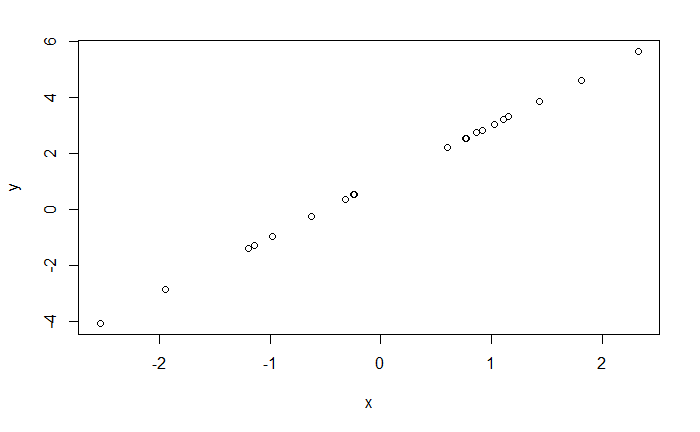

```r
DT[,{
  print(mean(x))
  plot(x,y)
}]
```

Ici on a affiché à l’écran la valeur de `mean(x)` puis on a fait le dessin souhaité et enfin on a obtenu le `data.table` égal à `NULL` à cause de la valeur de retour de la fonction `plot()` qui est `NULL`. Tout le bloc délimité par `{}`a été évalué dans l’environement de `DT` où les variables `x`, `y` et `z` sont définies.

Attention :

```
$breaks
[1] -3 -2 -1  0  1  2  3

$counts
[1] 1 3 5 5 5 1

$density
[1] 0.05 0.15 0.25 0.25 0.25 0.05

$mids
[1] -2.5 -1.5 -0.5  0.5  1.5  2.5

$xname
[1] "x"

$equidist
[1] TRUE

attr(,"class")
[1] "histogram"
```

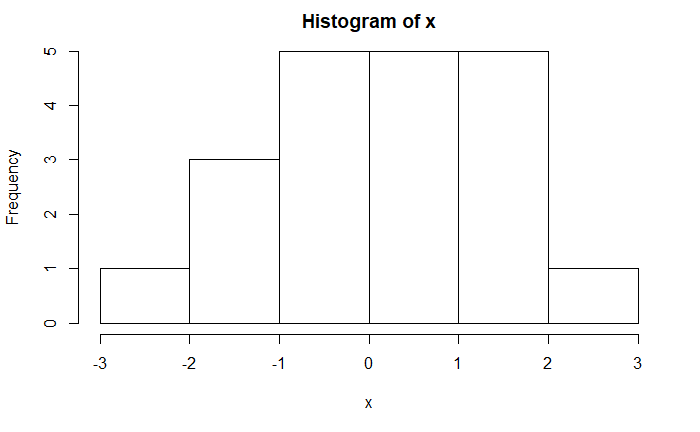

```r
DT[,{
  hist(x)
}]
```

```r
DT
```

| x | y | z |
| --- | --- | --- |
| -1.1988600 | -1.4045196 | a |
| 1.1499418 | 3.3071507 | b |
| -1.9443946 | -2.8846166 | a |
| -0.3191848 | 0.3644180 | b |
| -0.6287304 | -0.2611590 | a |
| 1.8109506 | 4.6054705 | b |
| -0.2455627 | 0.5172235 | a |
| -1.1424374 | -1.2892339 | b |
| 1.4309745 | 3.8417864 | a |
| 0.7673159 | 2.5297265 | b |

[output cut: 10 more lines]

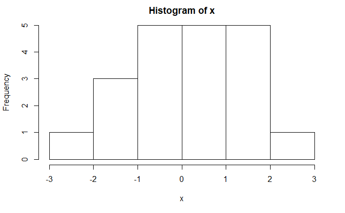

```r
DT[,{
  hist(x)
  NULL
}]
```

```r
DT
```

| x | y | z |
| --- | --- | --- |
| -1.1988600 | -1.4045196 | a |
| 1.1499418 | 3.3071507 | b |
| -1.9443946 | -2.8846166 | a |
| -0.3191848 | 0.3644180 | b |
| -0.6287304 | -0.2611590 | a |
| 1.8109506 | 4.6054705 | b |
| -0.2455627 | 0.5172235 | a |
| -1.1424374 | -1.2892339 | b |
| 1.4309745 | 3.8417864 | a |
| 0.7673159 | 2.5297265 | b |

[output cut: 10 more lines]

## Les groupes

Nous avons vu les deux premiers arguments de la syntaxe des `data.table`. Reste à comprendre le fonctionnement de `by`.

Pour donner une idée, on peut dire que `DT[i, j, by]` peut se lire *Sur les données `DT`, filtrer les lignes `i` puis calculer `j` sur les groupes `by`*. Par exemple pour calculer les moyennes de `x` et de `y` en fonction de la valeur de la variable `z` (qui peut valoir `"a"` ou `"b"`) on code :

```r
DT[,.(mean_x = mean(x), mean_y= mean(y)), by=z]
```

| z | mean_x | mean_y |
| --- | --- | --- |
| a | -0.3313707 | 0.3340229 |
| b | 0.6850440 | 2.3673939 |

Si l’on souhaite calculer la moyenne de `y` en différentiant les `x>0` des `x<0` on peut coder :

```r
DT[,.(mean_y = mean(y)), by = x>0]
```

| x | mean_y |
| --- | --- |
| FALSE | -1.052341 |
| TRUE | 3.316840 |

On peut améliorer la lisibilité de la sortie en renommant la variable `x`.

```r
DT[,.(mean_y = mean(y)), by = .(x_positif = x>0)]
```

| x_positif | mean_y |
| --- | --- |
| FALSE | -1.052341 |
| TRUE | 3.316840 |

Si l’on souhaite savoir combien de lignes correpondent à des valeurs positives de `x` c’est très simple on ajoute une colonne :

```r
DT[,.(mean_y = mean(y), .N), by = .(x_positif = x>0)]
```

| x_positif | mean_y | N |
| --- | --- | --- |
| FALSE | -1.052341 | 9 |
| TRUE | 3.316840 | 11 |

Ici la variable nommée `N` a été crée mais on peut toujours changer son nom.

## Une chose amusante

Sans commentaire

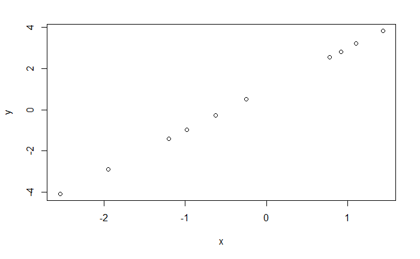

| z |
| --- |

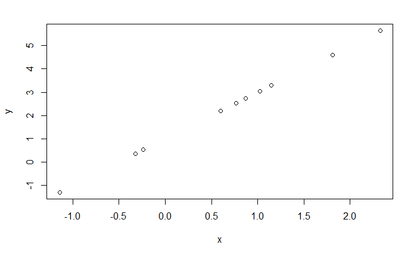

```r
DT[,plot(x, y)
   ,by=.(z)]
```

# Notions plus avancées

## Le chaînage

Vu que la manipulation d’un `data.table` via la syntaxe `DT[i, j, by]`renvoie un `data.table`[^1], on peut facilement chaîner les opérations :

```r
DT[,.(cs_y = cumsum(y)), by=.(x_positif=x>0, z)][
  ,.(mean_y=mean(y)), by=z]
```

| z | mean_y |
| --- | --- |
| a | 1.350708 |
| b | 1.350708 |

Faire les opérations sans chaînage pour bien comprendre.

## Les variables `.SD` et `.SDcols`

Ces variables sont définies dans l’environement des `data.table` lorsque l’argument `by` est utilisé. La variable `.SD` est en lien avec le sous-ensemble des données qui correspond à chaque valeur unique de l’argument `by`. Euh ??? par exemple :

```r
DT[, lapply(.SD, mean), by=z]
```

| z | x | y |
| --- | --- | --- |
| a | -0.3313707 | 0.3340229 |
| b | 0.6850440 | 2.3673939 |

On rapelle (sinon le vérifier) que `lapply` renvoie une liste ! C’est compatible avec la syntaxe vue ci-dessus.

On peut spécifier quelles colonnes de `DT` feront partie de la variable *interne* `.SD`. Par exemple :

```r
DT[, lapply(.SD, mean), by=z, .SDcols=c("x")]
```

| z | x |
| --- | --- |
| a | -0.3313707 |
| b | 0.6850440 |

## L’opérateur `:=` dans l’argument `j`

Cet élément syntaxique permet la modification **par référence** du `data.table`. C’est un élément clé de `data.table` lorsqu’on travaille sur de très grosses bases de données. On n’est pas obligé de faire une copie en mémoire de la table sur laquelle on travaille à chaque manipulation (comme on le fait systématiquement avec `dplyr`). Puisque `data.table` est conçu pour travailler sur des bases de données énormes (plusiuers centaines de Go en RAM) c’est un atout décisif.

Voici comment créer, modifier ou supprimer des colonnes :

```r
DT[,c("x", "y") := .(x**2, y**3)]
DT
```

| x | y | z |
| --- | --- | --- |
| 1.43726540 | -2.77066110 | a |
| 1.32236622 | 36.17111958 | b |
| 3.78067042 | -24.00293316 | a |
| 0.10187893 | 0.04839489 | b |
| 0.39530194 | -0.01781209 | a |
| 3.27954214 | 97.68367925 | b |
| 0.06030104 | 0.13836767 | a |
| 1.30516312 | -2.14286667 | b |
| 2.04768796 | 56.70216435 | a |
| 0.58877364 | 16.18902594 | b |

[output cut: 10 more lines]

Lorsqu’il n’y a qu’une seule variable il existe un *sucre* syntaxique et l’on peut écrire

```r
DT[, t := rep(NA, .N)]
DT
```

| x | y | z | t |
| --- | --- | --- | --- |
| 1.43726540 | -2.77066110 | a | NA |
| 1.32236622 | 36.17111958 | b | NA |
| 3.78067042 | -24.00293316 | a | NA |
| 0.10187893 | 0.04839489 | b | NA |
| 0.39530194 | -0.01781209 | a | NA |
| 3.27954214 | 97.68367925 | b | NA |
| 0.06030104 | 0.13836767 | a | NA |
| 1.30516312 | -2.14286667 | b | NA |
| 2.04768796 | 56.70216435 | a | NA |
| 0.58877364 | 16.18902594 | b | NA |

[output cut: 10 more lines]

au lieu de

```r
DT[,c("t") := .(rep(0, .N))]
DT
```

| x | y | z | t |
| --- | --- | --- | --- |
| 1.43726540 | -2.77066110 | a | 0 |
| 1.32236622 | 36.17111958 | b | 0 |
| 3.78067042 | -24.00293316 | a | 0 |
| 0.10187893 | 0.04839489 | b | 0 |
| 0.39530194 | -0.01781209 | a | 0 |
| 3.27954214 | 97.68367925 | b | 0 |
| 0.06030104 | 0.13836767 | a | 0 |
| 1.30516312 | -2.14286667 | b | 0 |
| 2.04768796 | 56.70216435 | a | 0 |
| 0.58877364 | 16.18902594 | b | 0 |

[output cut: 10 more lines]

Si l’on souhaite supprimer la colonne `t` nouvellement créée c’est très simple :

```r
DT[,t := NULL]
DT
```

| x | y | z |
| --- | --- | --- |
| 1.43726540 | -2.77066110 | a |
| 1.32236622 | 36.17111958 | b |
| 3.78067042 | -24.00293316 | a |
| 0.10187893 | 0.04839489 | b |
| 0.39530194 | -0.01781209 | a |
| 3.27954214 | 97.68367925 | b |
| 0.06030104 | 0.13836767 | a |
| 1.30516312 | -2.14286667 | b |
| 2.04768796 | 56.70216435 | a |
| 0.58877364 | 16.18902594 | b |

[output cut: 10 more lines]

Enfin il existe une forme fonctionnelle qui permet souvent une meilleur lisibilité mais qui est moins pratique dans un contexte de programmation :

```r
DT[, `:=`(
  x = rnorm(20),
  y = rnorm(20)
)]
DT
```

| x | y | z |
| --- | --- | --- |
| -0.89684846 | 0.93195423 | a |
| -0.20585362 | -0.09605751 | b |
| -0.27488377 | -1.18382120 | a |
| -0.50681300 | 0.63561539 | b |
| 1.92744985 | 2.33989030 | a |
| 0.33817248 | -1.80676074 | b |
| -0.63063458 | 0.08239464 | a |
| 0.05390888 | -0.79609945 | b |
| 0.92490804 | -1.91688957 | a |
| -0.84240946 | 1.51934727 | b |

[output cut: 10 more lines]

## Modifer le nom et l’ordre des colonnes

Il existe deux fonctions pour effectuer ces opérations (toujours par référence) : `setnames()` et `setcolorder()`. Voici deux exemples :

```r
setnames(DT, toupper(colnames(DT)))
DT
```

| X | Y | Z |
| --- | --- | --- |
| -0.89684846 | 0.93195423 | a |
| -0.20585362 | -0.09605751 | b |
| -0.27488377 | -1.18382120 | a |
| -0.50681300 | 0.63561539 | b |
| 1.92744985 | 2.33989030 | a |
| 0.33817248 | -1.80676074 | b |
| -0.63063458 | 0.08239464 | a |
| 0.05390888 | -0.79609945 | b |
| 0.92490804 | -1.91688957 | a |
| -0.84240946 | 1.51934727 | b |

[output cut: 10 more lines]

```r
setcolorder(DT, c("Z", "Y", "X"))
DT
```

| Z | Y | X |
| --- | --- | --- |
| a | 0.93195423 | -0.89684846 |
| b | -0.09605751 | -0.20585362 |
| a | -1.18382120 | -0.27488377 |
| b | 0.63561539 | -0.50681300 |
| a | 2.33989030 | 1.92744985 |
| b | -1.80676074 | 0.33817248 |
| a | 0.08239464 | -0.63063458 |
| b | -0.79609945 | 0.05390888 |
| a | -1.91688957 | 0.92490804 |
| b | 1.51934727 | -0.84240946 |

[output cut: 10 more lines]

[^1]: On rappelle l’exception `DT[,x]` qui renvoie un vecteur